# Data Visualization in R (Light Focus)

#### Bar Plots

Bar plots are useful for comparing quantities corresponding to different groups.

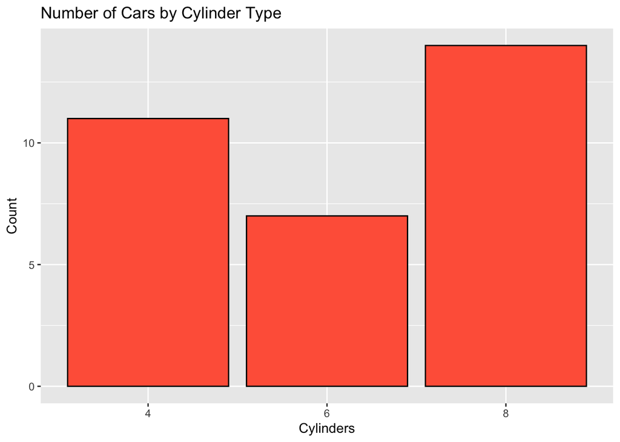

```r
# Convert cyl (number of cylinders) to a factor for a bar plot
mtcars$cyl <- as.factor(mtcars$cyl)

# Creating a bar plot of car counts per cylinder type
ggplot(mtcars, aes(x = cyl)) +
  geom_bar(fill = "tomato", color = "black") +
  labs(title = "Number of Cars by Cylinder Type", x = "Cylinders", y = "Count")
```

#### Scatter Plots

Scatter plots are ideal for examining the relationship between two continuous variables.

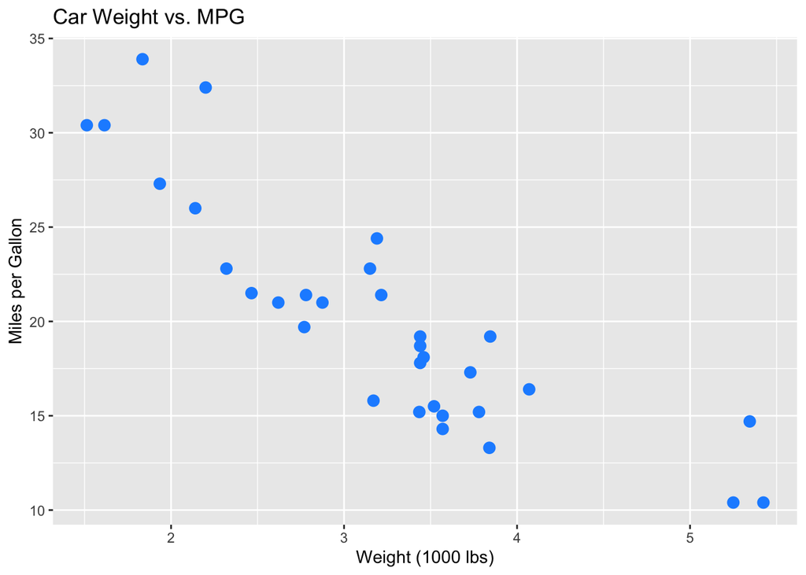

```r
# Creating a scatter plot of mpg vs wt
ggplot(mtcars, aes(x = wt, y = mpg)) +
  geom_point(size = 3, color = "dodgerblue") +
  labs(title = "Car Weight vs. MPG", x = "Weight (1000 lbs)", y = "Miles per Gallon")
```

### Aesthetics and Themes

`ggplot2` allows extensive customization of plots through aesthetics and themes, enabling you to make plots more informative and appealing.

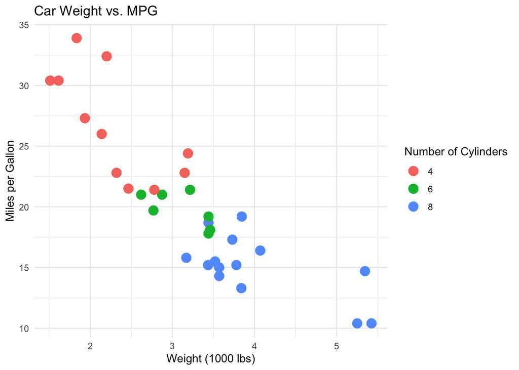

```r
# Enhancing scatter plot with themes and labels
ggplot(mtcars, aes(x = wt, y = mpg, color = cyl)) +  # Color points by cylinder count
  geom_point(size = 4) +
  labs(title = "Car Weight vs. MPG",
       x = "Weight (1000 lbs)",
       y = "Miles per Gallon",
       color = "Number of Cylinders") +
  theme_minimal()  # Using a minimal theme
```

These examples demonstrate basic `ggplot2` usage for creating various types of plots, setting the stage for more advanced visualization techniques. Each type of plot serves different purposes and can be tailored extensively using `ggplot2`’s powerful customization options.

## Customizing Graphs for Data Presentation

Visualizing data effectively involves more than just creating basic plots; it requires customization to enhance clarity and impact. This section of the course will teach you how to customize axes, legends, and labels, fine-tune scales and coordinates, and add annotations and custom geometries using ggplot2 in R.

## Customizing Axes, Legends, and Labels

Customizing the textual components of your plots helps in making them more readable and informative. `ggplot2` allows for detailed adjustments to these elements.

### Customizing Axes

You can modify the text of axis labels and adjust the axis limits to focus on specific areas of the data.

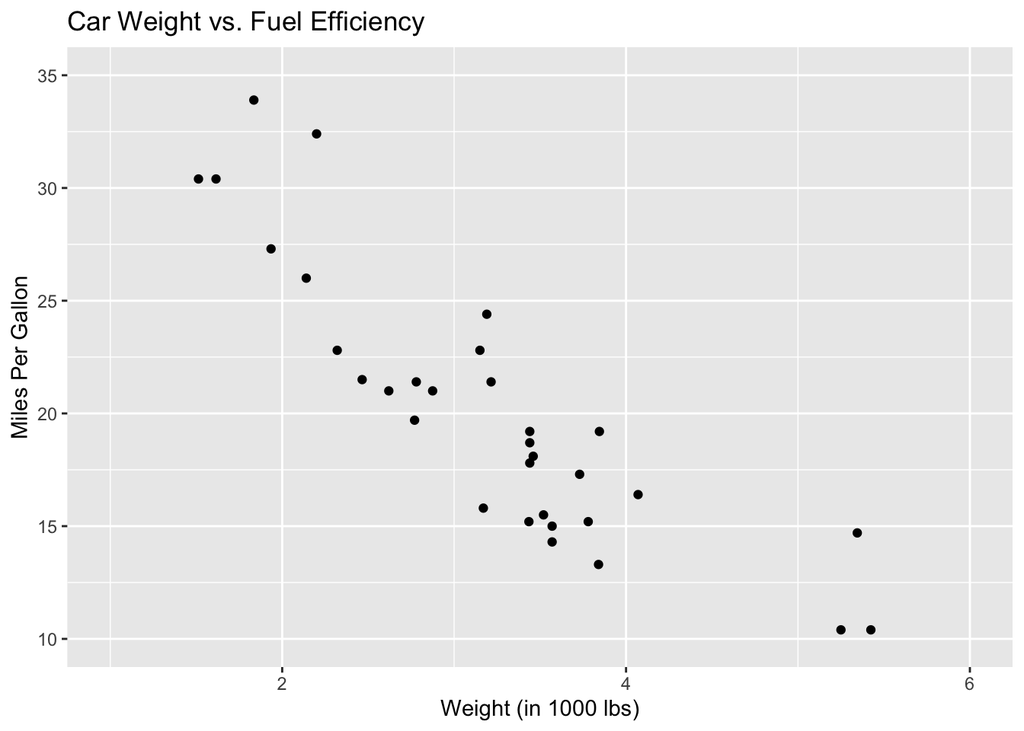

```r
# Example of customizing axes
ggplot(mtcars, aes(x = wt, y = mpg)) +
  geom_point() +
  scale_x_continuous("Weight (in 1000 lbs)", limits = c(1, 6)) +
  scale_y_continuous("Miles Per Gallon", limits = c(10, 35)) +
  labs(title = "Car Weight vs. Fuel Efficiency")
```

### Customizing Legends

Adjusting the legend involves changing its title, text, and position to improve the overall aesthetics and readability.

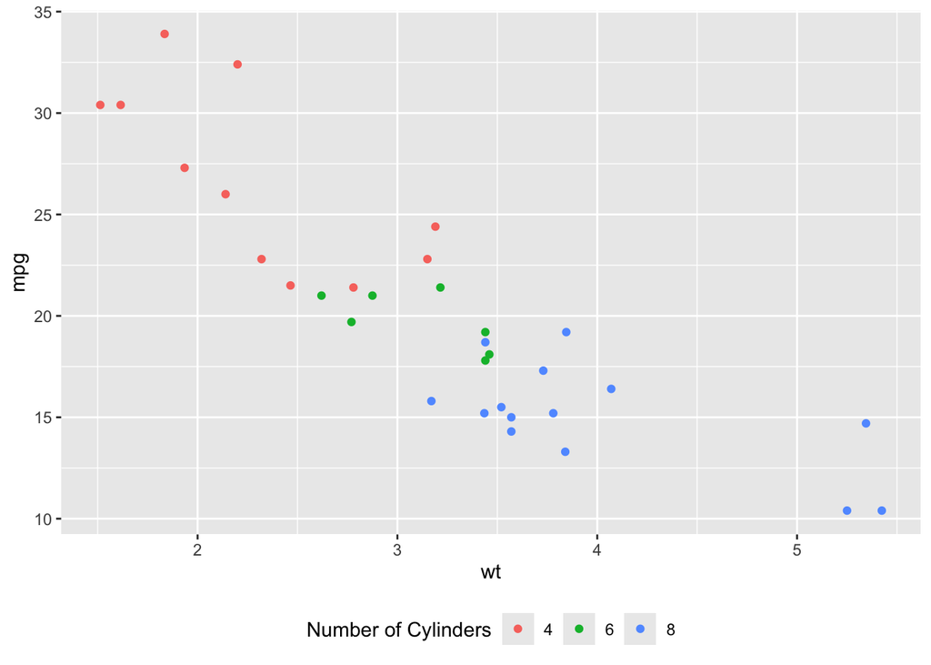

```r
# Example of customizing legends
ggplot(mtcars, aes(x = wt, y = mpg, color = factor(cyl))) +
  geom_point() +
  labs(color = "Number of Cylinders") +
  theme(legend.position = "bottom")
```

### Customizing Labels

Labels for the entire plot, axes, and legends can be styled to enhance clarity or to align with publication standards or personal preferences.

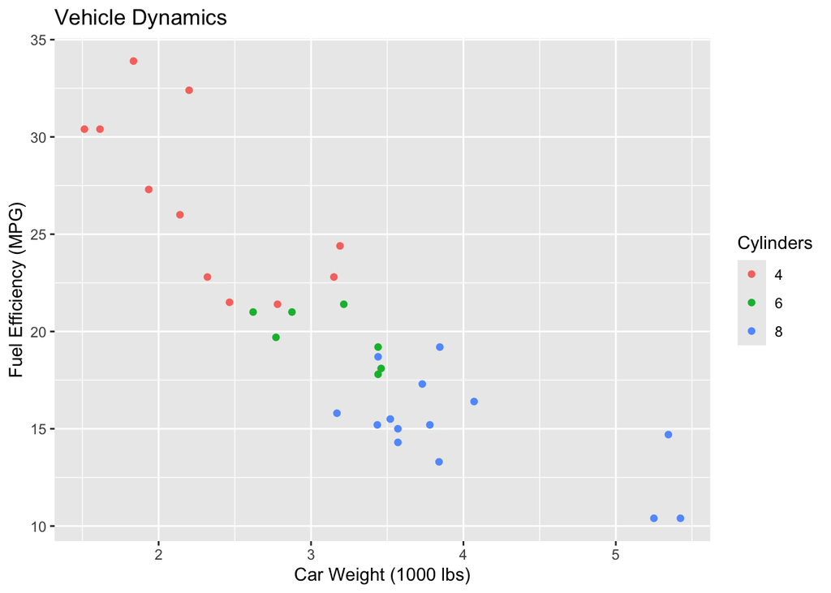

```r
# Example of customizing labels
ggplot(mtcars, aes(x = wt, y = mpg, color = factor(cyl))) +
  geom_point() +
  labs(
    title = "Vehicle Dynamics",
    x = "Car Weight (1000 lbs)",
    y = "Fuel Efficiency (MPG)",
    color = "Cylinders"
  )
```